# hw2

Wanjia Guo

11/11/2021

# Part 1: Predicting a Categorical Outcome using Regularized Logistic Regression

```r
# Load the following packages needed for modeling in this assignment

require(caret)
require(recipes)
require(finalfit)
require(glmnet)
require(cutpointr)
set.seed(315)

# Import the tweet dataset with embeddings

tweet <- read.csv('https://raw.githubusercontent.com/uo-datasci-specialization/c4-ml-fall-2021/main/content/post/hw2/data/hw1_tweet_final.csv',header=TRUE)

# Recipe for the tweet dataset

blueprint_tweet <- recipe(x  = tweet,
                          vars  = colnames(tweet),
                          roles = c('outcome',rep('predictor',772))) %>%
  step_dummy('month',one_hot=TRUE) %>%
  step_harmonic('day',frequency=1,cycle_size=7, role='predictor') %>%
  step_harmonic('date',frequency=1,cycle_size=31,role='predictor') %>%
  step_harmonic('hour',frequency=1,cycle_size=24,role='predictor') %>%
  step_normalize(paste0('Dim',1:768)) %>%
  step_normalize(c('day_sin_1','day_cos_1',
                   'date_sin_1','date_cos_1',
                   'hour_sin_1','hour_cos_1')) %>%
  step_num2factor(sentiment,
                  transform = function(x) x + 1,
                  levels=c('Negative','Positive'))


    # Notice that I explicitly specified role=predictor when using
    # step_harmonic function. This assures that the newly derived sin and cos
    # variables has a defined role.
    # You need to do this otherwise caret::train function breaks.
    # caret_train requires every variable in the recipe to have a role

    # You can run the following code and make sure every variable has a defined
    # role. If you want to experiment, remove the role=predictor argument
    # in the step_harmonic function, create the recipe again, and run the following
    # you will see that the new sin and cos variables have NA in the column role
    # and this breaks the caret::train function later.

    # Also, in the last line, we transform the outcome variable 'sentiment' to
    # a factor with labels.
    # This seems necessary for fitting logistic regression via caret::train

    #View(blueprint_tweet %>% prep() %>% summary)
```

### Task 1.1. Split the original data into two subsets: training and test. Let the training data have the 80% of cases and the test data have the 20% of the cases.

```r
loc      <- sample(1:nrow(tweet), round(nrow(tweet) * 0.8))
df_tr  <- tweet[loc, ]
df_te  <- tweet[-loc, ]
```

### Task 1.2. Use the caret::train() function to train a model with 10-fold cross-validation for predicting the probability of sentiment being positive using logistic regression without any regularization. Evaluate and report the performance of the model on the test dataset.

```r
# Randomly shuffle the data

df_tr = df_tr[sample(nrow(df_tr)),]

# Create 10 folds with equal size

folds = cut(seq(1,nrow(df_tr)),breaks=10,labels=FALSE)

# Create the list for each fold

my.indices <- vector('list',10)
for(i in 1:10){
  my.indices[[i]] <- which(folds!=i)
}

cv <- trainControl(method = "cv",
             index  = my.indices,
             classProbs = TRUE,
             summaryFunction = mnLogLoss)

vanilla <- train(blueprint_tweet,
                  data      = df_tr,
                  method    = "glm",
                  family    = 'binomial',
                  metric    = 'logLoss',
                  trControl = cv)
predicted_te <- predict(vanilla, df_te, type='prob')
dim(predicted_te)
```

```
## [1] 300   2
```

```r
head(predicted_te)
```

```
##       Negative     Positive
## 1 2.220446e-16 1.000000e+00
## 2 2.220446e-16 1.000000e+00
## 3 1.000000e+00 2.220446e-16
## 4 2.220446e-16 1.000000e+00
## 5 2.220446e-16 1.000000e+00
## 6 1.000000e+00 2.220446e-16
```

```r
cut.obj <- cutpointr(x     = predicted_te$Positive,
                     class = df_te$sentiment)
```

```
## Assuming the positive class is 1
```

```
## Assuming the positive class has higher x values
```

```r
vanilla_auc = auc(cut.obj)

vanilla_auc
```

```
## [1] 0.7080388
```

```r
# Confusion matrix

pred_class <- ifelse(predicted_te$Positive>.5,1,0)

vanilla_confusion <- table(df_te$sentiment,pred_class)

vanilla_confusion
```

```
##    pred_class
##       0   1
##   0  94  53
##   1  51 102
```

```r
vanilla_ACC = (vanilla_confusion[2,2]+vanilla_confusion[1,1])/sum(vanilla_confusion)

vanilla_ACC
```

```
## [1] 0.6533333
```

```r
vanilla_TPR = vanilla_confusion[2,2]/(vanilla_confusion[2,1]+vanilla_confusion[2,2])

vanilla_TPR
```

```
## [1] 0.6666667
```

```r
vanilla_TNR = vanilla_confusion[1,1]/(vanilla_confusion[1,1]+vanilla_confusion[1,2])

vanilla_TNR
```

```
## [1] 0.6394558
```

```r
vanilla_PRE = vanilla_confusion[2,2]/(vanilla_confusion[1,2]+vanilla_confusion[2,2])

vanilla_PRE
```

```
## [1] 0.6580645
```

### Task 1.3. Use the caret::train() function to train a model with 10-fold cross-validation for predicting the probability of sentiment being positive using logistic regression with ridge penalty. Try different values of ridge penalty to decide the optimal value. Use logLoss as a metric for optimization. Plot the results, and report the optimal value of ridge penalty.

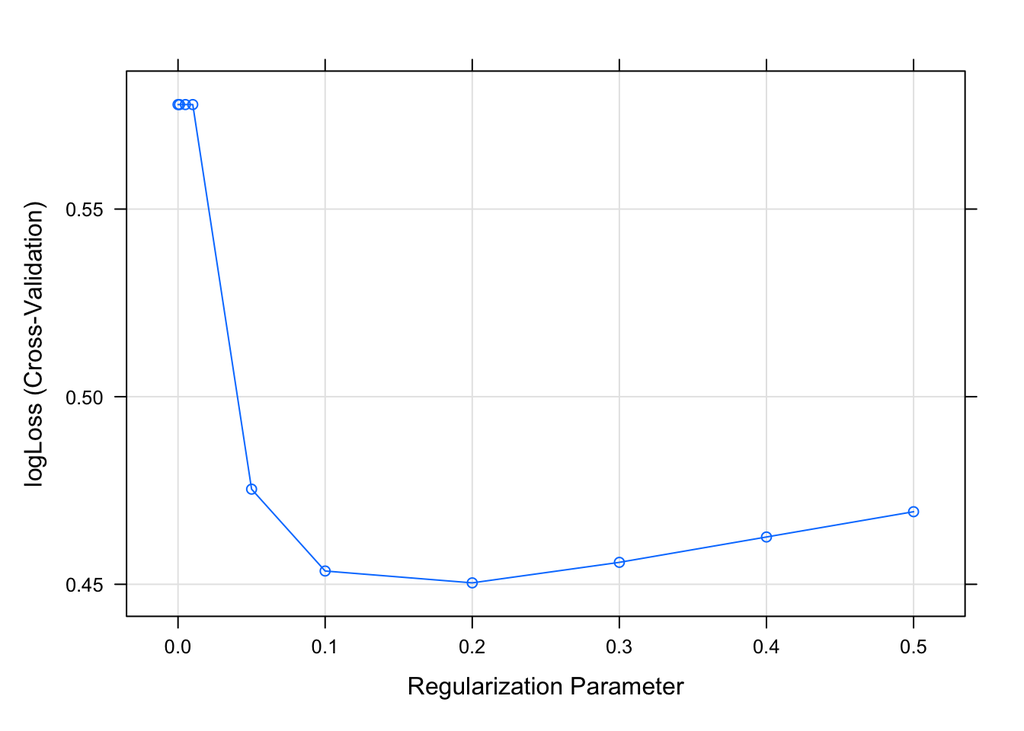

```r
# Hyperparameter tuning grid for ridge penalty (lambda), alpha = 0

grid <- data.frame(alpha = 0, lambda = c(0,.001,.005,.01,.05,.1,.2,.3,.4,.5))

ridge <- train(blueprint_tweet,
                  data      = df_tr,
                  method    = "glmnet",
                  family    = 'binomial',
                  metric    = 'logLoss',
                  trControl = cv,
                  tuneGrid = grid)

plot(ridge)
```

```r
ridge$bestTune
```

```
##   alpha lambda
## 7     0    0.2
```

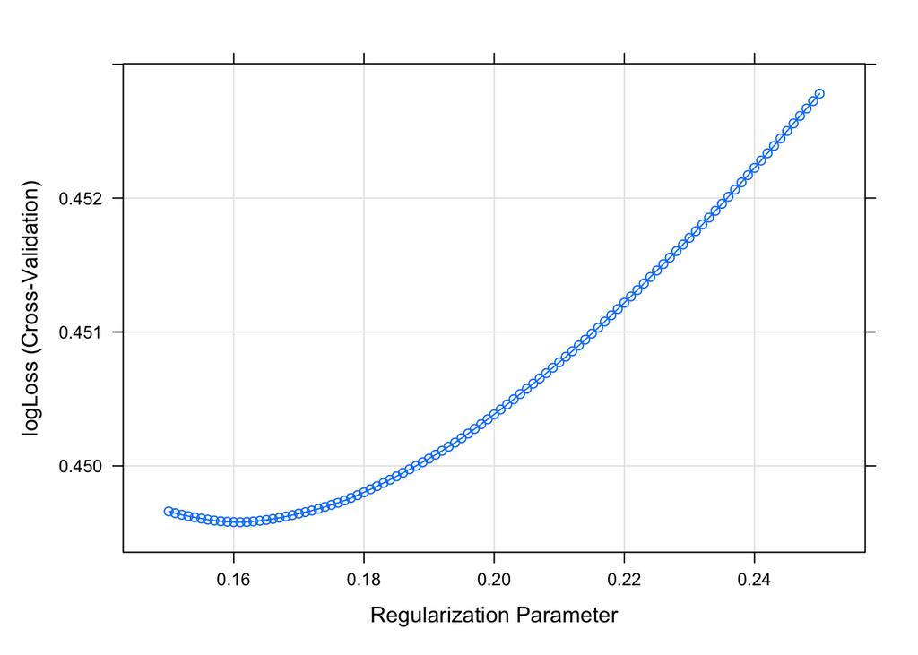

```r
grid <- data.frame(alpha = 0, lambda = seq(.15,.25,.001))
ridge <- train(blueprint_tweet,
                  data      = df_tr,
                  method    = "glmnet",
                  family    = 'binomial',
                  metric    = 'logLoss',
                  trControl = cv,
                  tuneGrid = grid)

plot(ridge)
```

```r
ridge$bestTune
```

```
##    alpha lambda
## 12     0  0.161
```

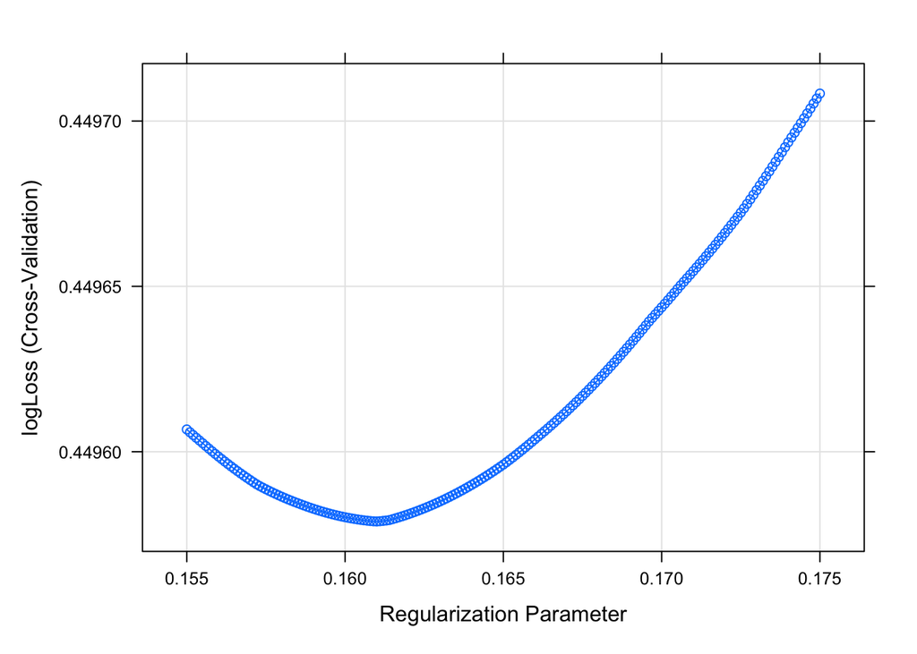

```r
grid <- data.frame(alpha = 0, lambda = seq(.155,.175,.0001))
ridge <- train(blueprint_tweet,
                  data      = df_tr,
                  method    = "glmnet",
                  family    = 'binomial',
                  metric    = 'logLoss',
                  trControl = cv,
                  tuneGrid = grid)

plot(ridge)
```

```r
ridge$bestTune
```

```
##    alpha lambda
## 61     0  0.161
```

```r
predicted_te <- predict(ridge, df_te, type='prob')

cut.obj <- cutpointr(x     = predicted_te$Positive,
                     class = df_te$sentiment)
```

```
## Assuming the positive class is 1
```

```
## Assuming the positive class has higher x values
```

```r
ridge_auc = auc(cut.obj)

ridge_auc
```

```
## [1] 0.8920902
```

```r
# Confusion matrix

pred_class <- ifelse(predicted_te$Positive>.5,1,0)

ridge_confusion <- table(df_te$sentiment,pred_class)

ridge_confusion
```

```
##    pred_class
##       0   1
##   0 121  26
##   1  22 131
```

```r
ridge_ACC = (ridge_confusion[2,2]+ridge_confusion[1,1])/sum(ridge_confusion)

ridge_ACC
```

```
## [1] 0.84
```

```r
ridge_TPR = ridge_confusion[2,2]/(ridge_confusion[2,1]+ridge_confusion[2,2])

ridge_TPR
```

```
## [1] 0.8562092
```

```r
ridge_TNR = ridge_confusion[1,1]/(ridge_confusion[1,1]+ridge_confusion[1,2])

ridge_TNR
```

```
## [1] 0.8231293
```

```r
ridge_PRE = ridge_confusion[2,2]/(ridge_confusion[1,2]+ridge_confusion[2,2])

ridge_PRE
```

```
## [1] 0.8343949
```

### Task 1.4. Use the caret::train() function to train a model with 10-fold cross-validation for predicting the probability of sentiment being positive using logistic regression with lasso penalty. Try different values of lasso penalty to decide optimal value. Use logLoss as a metric for optimization. Plot the results, and report the optimal value of lasso penalty.

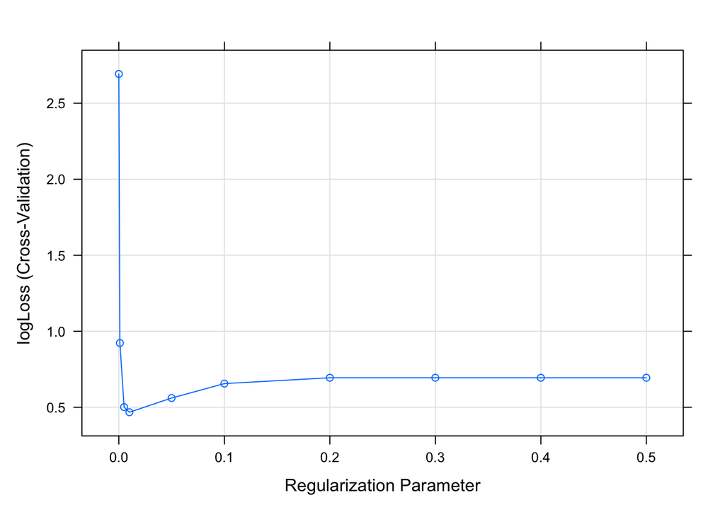

```r
grid <- data.frame(alpha = 1, lambda = c(0, .001,.005,.01,.05,.1,.2,.3,.4,.5))

lasso <- train(blueprint_tweet,
                  data      = df_tr,
                  method    = "glmnet",
                  family    = 'binomial',
                  metric    = 'logLoss',
                  trControl = cv,
                  tuneGrid = grid)

plot(lasso)
```

```r
lasso$bestTune
```

```
##   alpha lambda
## 4     1   0.01
```

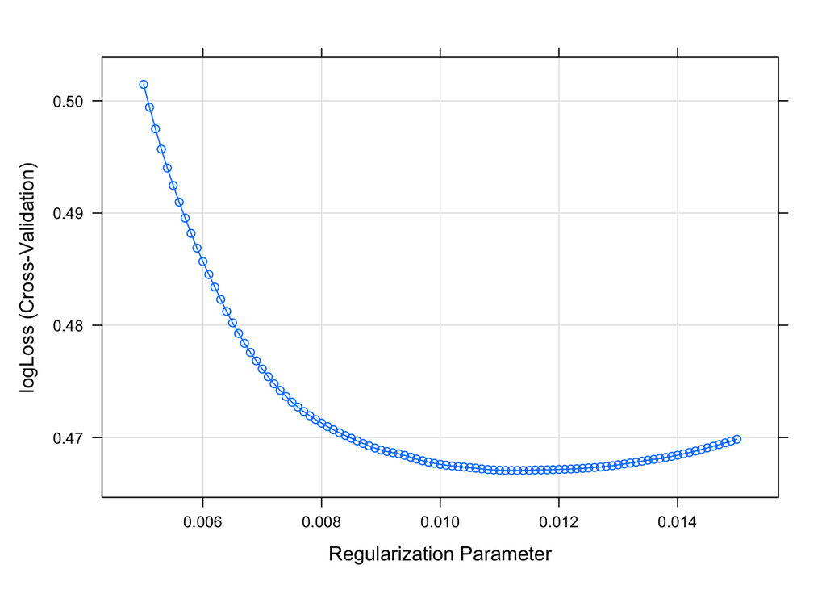

```r
grid <- data.frame(alpha = 1, lambda = seq(.005,.015,.0001))

lasso <- train(blueprint_tweet,
                  data      = df_tr,
                  method    = "glmnet",
                  family    = 'binomial',
                  metric    = 'logLoss',
                  trControl = cv,
                  tuneGrid = grid)

plot(lasso)
```

```r
lasso$bestTune
```

```
##    alpha lambda
## 64     1 0.0113
```

```r
predicted_te <- predict(lasso, df_te, type='prob')

cut.obj <- cutpointr(x     = predicted_te$Positive,
                     class = df_te$sentiment)
```

```
## Assuming the positive class is 1
```

```
## Assuming the positive class has higher x values
```

```r
lasso_auc = auc(cut.obj)

lasso_auc
```

```
## [1] 0.8925348
```

```r
# Confusion matrix

pred_class <- ifelse(predicted_te$Positive>.5,1,0)

lasso_confusion <- table(df_te$sentiment,pred_class)

lasso_confusion
```

```
##    pred_class
##       0   1
##   0 121  26
##   1  27 126
```

```r
lasso_ACC = (lasso_confusion[2,2]+lasso_confusion[1,1])/sum(lasso_confusion)

lasso_ACC
```

```
## [1] 0.8233333
```

```r
lasso_TPR = lasso_confusion[2,2]/(lasso_confusion[2,1]+lasso_confusion[2,2])

lasso_TPR
```

```
## [1] 0.8235294
```

```r
lasso_TNR = lasso_confusion[1,1]/(lasso_confusion[1,1]+lasso_confusion[1,2])

lasso_TNR
```

```
## [1] 0.8231293
```

```r
lasso_PRE = lasso_confusion[2,2]/(lasso_confusion[1,2]+lasso_confusion[2,2])

lasso_PRE
```

```
## [1] 0.8289474
```

### Task 1.5 Evaluate the performance of the models in 1.2, 1.3, and 1.4 on the test dataset. Calculate and report logLoss (LL), area under the reciever operating characteristic curver (AUC), overall accuracy (ACC), true positive rate (TPR), true negative rate (TNR), and precision (PRE) for three models. When calculating ACC, TPR, TNR, and PRE, assume that we use a cut-off value of 0.5 for the predicted probabilities. Summarize these numbers in a table like the following. Decide and comment on which model you would use to predict sentiment of a tweet moving forward.

```r
name <- c('Logistic Regression', 'Logistic Regression with Ridge Penalty', 'Logistic Regression with Lasso Penalty')
ridge$results %>% filter(lambda == ridge$bestTune$lambda) %>% .$logLoss
```

```
## [1] 0.4495789
```

```r
LL <- c(vanilla$results$logLoss,
        ridge$results %>% filter(lambda == ridge$bestTune$lambda) %>% .$logLoss,
        lasso$results %>% filter(lambda == lasso$bestTune$lambda) %>% .$logLoss)
AUC <- c(vanilla_auc, ridge_auc, lasso_auc)
ACC <- c(vanilla_ACC, ridge_ACC, lasso_ACC)
TPR <- c(vanilla_TPR, ridge_TPR, lasso_TPR)
TNR <- c(vanilla_TNR, ridge_TNR, lasso_TNR)
PRE <- c(vanilla_PRE, ridge_PRE, lasso_PRE)

summary_df <- data.frame(name, LL, AUC, ACC, TPR, TNR, PRE)

summary_df
```

```
##                                     name        LL       AUC       ACC
## 1                    Logistic Regression 9.7851403 0.7080388 0.6533333
## 2 Logistic Regression with Ridge Penalty 0.4495789 0.8920902 0.8400000
## 3 Logistic Regression with Lasso Penalty 0.4670683 0.8925348 0.8233333
##         TPR       TNR       PRE
## 1 0.6666667 0.6394558 0.6580645
## 2 0.8562092 0.8231293 0.8343949
## 3 0.8235294 0.8231293 0.8289474
```

### Task 1.6 For the model you decided in 1.5, find and report the most important 10 predictors of sentiment and their coefficients. Briefly comment which variables seem to be the most important predictors.

```r
coefs <- coef(ridge$finalModel,
              ridge$bestTune$lambda)

ind   <- order(abs(coefs[,1]),decreasing=T)

head(as.matrix(coefs[ind,]),10)
```

```
##                    [,1]
## month_Jun   -0.27885838
## month_May    0.26133554
## (Intercept)  0.20024176
## date_sin_1   0.18770811
## day_cos_1    0.16020301
## month_Apr    0.14085231
## date_cos_1   0.12974592
## Dim311      -0.10463843
## Dim282      -0.09814034
## Dim33        0.09201515
```

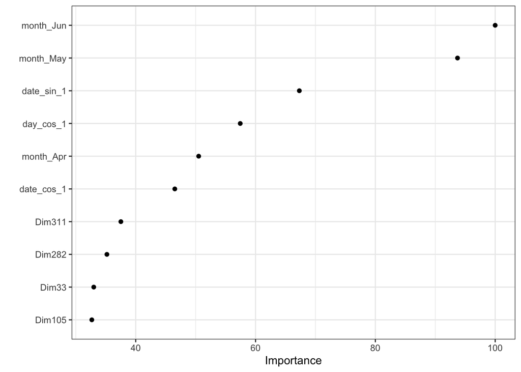

```r
vip::vip(ridge, num_features = 10, geom = "point") +
  theme_bw()
```

### Task 1.7. Below are the two tweets I picked from my timeline. Use the model you decided in Task 1.5 to predict a probability that the sentiment being positive for these tweets. You are welcome to extract the word embeddings for these tweets by yourself (model: roberta-base, layer=12). Assume that all these tweets are posted on Saturday, May 1, 2021 at 12pm. For convenience, you can also download the dataset from the link below in case you have trouble in extracting the word embeddings.

```r
new_tweets <- read.csv('https://raw.githubusercontent.com/uo-datasci-specialization/c4-ml-fall-2021/main/content/post/hw2/data/toy_tweet_embeddings.csv',header=TRUE)

predicted_te <- predict(ridge, new_tweets, type='prob')

predicted_te
```

```
##    Negative  Positive
## 1 0.6380705 0.3619295
## 2 0.5698300 0.4301700
```

Both tweets are evaluated as negative, which is kinda interesting and surprising. However, since we know the timing of the tweet influence the emotion, I think it is less suprising as we are using a fixed time for these two tweets.

### Task 1.8. Let’s do an experiment and test whether or not the model is biased against certain groups when detecting sentiment of a given text. Below you will find 10 hypothetical tweets with an identical structure. The only thing that changes from tweet to tweet is the subject. You are welcome to extract the word embeddings for these tweets by yourself (model: roberta-base, layer=12). Assume that all these tweets are posted on Saturday, May 1, 2021 at 12pm. For convenience, you can also download the dataset from the link below in case you have trouble in extracting the word embeddings.

What do you think? Does your model favor any group or seem to be biased against any group? Provide a brief commentary (not more than 500 words).

```r
bias_check <- read.csv('https://raw.githubusercontent.com/uo-datasci-specialization/c4-ml-fall-2021/main/content/post/hw2/data/bias_check_tweet_embeddings.csv',header=TRUE)

predicted_te <- predict(ridge, bias_check, type='prob')

predicted_te
```

```
##     Negative  Positive
## 1  0.3872646 0.6127354
## 2  0.4740938 0.5259062
## 3  0.5043056 0.4956944
## 4  0.5152124 0.4847876
## 5  0.4789000 0.5211000
## 6  0.3524194 0.6475806
## 7  0.4064685 0.5935315
## 8  0.3759359 0.6240641
## 9  0.4487264 0.5512736
## 10 0.3350015 0.6649985
```

```r
names = c('Muslims', 'Jews', 'Christians', 'Atheists', 'Buddhists', 'Turkish people', 'French people', 'American people', 'Japanese people', 'Russian people')

summary_df = predicted_te %>% mutate(name = names,
                                     `Probability(Sentiment=Positive)` = Positive) %>%
  select(-c(Positive, Negative))


summary_df
```

```
##               name Probability(Sentiment=Positive)
## 1          Muslims                       0.6127354
## 2             Jews                       0.5259062
## 3       Christians                       0.4956944
## 4         Atheists                       0.4847876
## 5        Buddhists                       0.5211000
## 6   Turkish people                       0.6475806
## 7    French people                       0.5935315
## 8  American people                       0.6240641
## 9  Japanese people                       0.5512736
## 10  Russian people                       0.6649985
```

The lower the positive sentiment probability, the more correct the model is. Therefore, the model correctly judged the sentence for Christians and Atheists. However, not for the others. In particular, it is judged rather positive for Russian and Turkish people. I still feel it has to be heavily influenced by the date and time that the post is posted. As May as a heavy positive weight on the sentiment.

# Part 2: Predicting a Continous Outcome using Regularized Linear Regression

```r
# Import the oregon dataset

oregon <- read.csv('https://raw.githubusercontent.com/uo-datasci-specialization/c4-ml-fall-2021/main/content/post/hw2/data/hw1_oregon_final.csv',header=TRUE)

# Recipe for the oregon dataset

  outcome <- 'score'

  id      <- 'id'

  categorical <- c('sex','ethnic_cd','tst_bnch','migrant_ed_fg','ind_ed_fg',
                   'sp_ed_fg','tag_ed_fg','econ_dsvntg','stay_in_dist',
                   'stay_in_schl','dist_sped','trgt_assist_fg',
                   'ayp_dist_partic','ayp_schl_partic','ayp_dist_prfrm',
                   'ayp_schl_prfrm','rc_dist_partic','rc_schl_partic',
                   'rc_dist_prfrm','rc_schl_prfrm','grp_rpt_dist_partic',
                   'grp_rpt_schl_partic','grp_rpt_dist_prfrm',
                   'grp_rpt_schl_prfrm')

  numeric <- c('enrl_grd')

  cyclic <- c('date','month')


blueprint_oregon <- recipe(x     = oregon,
                    vars  = c(outcome,categorical,numeric,cyclic),
                    roles = c('outcome',rep('predictor',27))) %>%
  step_indicate_na(all_of(categorical),all_of(numeric)) %>%
  step_zv(all_numeric()) %>%
  step_impute_mean(all_of(numeric)) %>%
  step_impute_mode(all_of(categorical)) %>%
  step_harmonic('date',frequency=1,cycle_size=31,role='predictor') %>%
  step_harmonic('month',frequency=1,cycle_size=12,role='predictor') %>%
  step_ns('enrl_grd',deg_free=3) %>%
  step_normalize(c(paste0(numeric,'_ns_1'),paste0(numeric,'_ns_2'),paste0(numeric,'_ns_3'))) %>%
  step_normalize(c("date_sin_1","date_cos_1","month_sin_1","month_cos_1")) %>%
  step_dummy(all_of(categorical),one_hot=TRUE) %>%
  step_rm(c('date','month'))

  #View(blueprint_oregon %>% prep() %>% summary)
```

### Task 2.1. Check the dataset for missingness. If there is any variable with more than 75% missingness, remove these variables.

```r
missing_info = ff_glimpse(oregon)

missing_info$Categorical[,c('n','missing_percent')]
```

```
##                          n missing_percent
## sex                 189426             0.0
## ethnic_cd           189426             0.0
## tst_bnch            189426             0.0
## migrant_ed_fg       189426             0.0
## ind_ed_fg           189365             0.0
## sp_ed_fg            189365             0.0
## tag_ed_fg           188963             0.2
## econ_dsvntg         188895             0.3
## stay_in_dist        188963             0.2
## stay_in_schl        188963             0.2
## dist_sped           188963             0.2
## trgt_assist_fg      188956             0.2
## ayp_dist_partic     189426             0.0
## ayp_schl_partic     189426             0.0
## ayp_dist_prfrm      189426             0.0
## ayp_schl_prfrm      189426             0.0
## rc_dist_partic      189426             0.0
## rc_schl_partic      189426             0.0
## rc_dist_prfrm       189426             0.0
## rc_schl_prfrm       189426             0.0
## grp_rpt_dist_partic 189426             0.0
## grp_rpt_schl_partic 189426             0.0
## grp_rpt_dist_prfrm  189426             0.0
## grp_rpt_schl_prfrm  189426             0.0
```

```r
missing_info$Categorical[,c('n','missing_percent')] %>% filter(missing_percent >= 0.75)
```

```
## [1] n               missing_percent
## <0 rows> (or 0-length row.names)
```

```r
missing_info$Continuous[,c('n','missing_percent')]
```

```
##               n missing_percent
## id       189426             0.0
## enrl_grd 189426             0.0
## score    189426             0.0
## month    189426             0.0
## date     189426             0.0
```

```r
missing_info$Categorical[,c('n','missing_percent')] %>% filter(missing_percent >= 0.75)
```

```
## [1] n               missing_percent
## <0 rows> (or 0-length row.names)
```

I didnt find any variable that is missing for more than 75%.

### Task 2.2. Split the original data into two subsets: training and test. Let the training data have the 80% of cases and the test data have the 20% of the cases.

```r
loc      <- sample(1:nrow(oregon), round(nrow(oregon) * 0.8))
df2_tr  <- oregon[loc, ]
df2_te  <- oregon[-loc, ]
```

### Task 2.3. Use the caret::train() function to train a model with 10-fold cross-validation to predict the scores using linear regression without any regularization. Evaluate the performance of the model on both training and test datasets. Evaluate and report RMSE, R-square, and MAE for both training and test datasets. Is there any evidence of overfitting?

```r
df2_tr = df2_tr[sample(nrow(df2_tr)),]

# Create 10 folds with equal size

folds = cut(seq(1,nrow(df2_tr)),breaks=10,labels=FALSE)

# Create the list for each fold

my.indices <- vector('list',10)

for(i in 1:10){
  my.indices[[i]] <- which(folds!=i)
}

cv <- trainControl(method = "cv",
                   index  = my.indices)

vanilla <- train(blueprint_oregon,
                 data      = df2_tr,
                 method    = "lm",
                 trControl = cv)
vanilla
```

```
## Linear Regression
##
## 151541 samples
##     28 predictor
##
## Recipe steps: indicate_na, zv, impute_mean, impute_mode, harmonic,
##  harmonic, ns, normalize, normalize, dummy, rm
## Resampling: Cross-Validated (10 fold)
## Summary of sample sizes: 136386, 136387, 136387, 136387, 136387, 136387, ...
## Resampling results:
##
##   RMSE      Rsquared   MAE
##   89.54934  0.4012329  69.49324
##
## Tuning parameter 'intercept' was held constant at a value of TRUE
```

```r
predicted_te <- predict(vanilla, df2_te)
rmse_te <- sqrt(mean((df2_te$score - predicted_te)^2))
rmse_te
```

```
## [1] 89.74221
```

```r
rsq_te <- cor(df2_te$score,predicted_te)^2
rsq_te
```

```
## [1] 0.403981
```

```r
mae_te <- mean(abs(df2_te$score - predicted_te))
mae_te
```

```
## [1] 69.49596
```

The performance between the training dateset and testing dataset are highly similar to each other, so there doesnt seem to have a problem of overfitting.

### Task 2.4. Use the caret::train() function to train a model with 10-fold cross-validation to predict the scores using ridge regression. Try different values of lambda to decide optimal value. Evaluate the performance of the model on the test dataset, and report RMSE, R-square, and MAE. Does ridge regression provide any improvement over linear regression with no regularization?

```r
grid <- data.frame(alpha = 0, lambda = c(0, .001,.005,.01,.05,.1,.2,.3,.4,.5))
                     #seq(0.01,3,.01))
grid
```

```
##    alpha lambda
## 1      0  0.000
## 2      0  0.001
## 3      0  0.005
## 4      0  0.010
## 5      0  0.050
## 6      0  0.100
## 7      0  0.200
## 8      0  0.300
## 9      0  0.400
## 10     0  0.500
```

```r
# Train the model

ridge <- train(blueprint_oregon,
                      data      = df2_tr,
                      method    = "glmnet",
                      trControl = cv,
                      tuneGrid  = grid)

ridge$results
```

```
##    alpha lambda     RMSE  Rsquared      MAE   RMSESD RsquaredSD     MAESD
## 1      0  0.000 89.52152 0.4016551 69.50437 1.084373 0.01011989 0.5660291
## 2      0  0.001 89.52152 0.4016551 69.50437 1.084373 0.01011989 0.5660291
## 3      0  0.005 89.52152 0.4016551 69.50437 1.084373 0.01011989 0.5660291
## 4      0  0.010 89.52152 0.4016551 69.50437 1.084373 0.01011989 0.5660291
## 5      0  0.050 89.52152 0.4016551 69.50437 1.084373 0.01011989 0.5660291
## 6      0  0.100 89.52152 0.4016551 69.50437 1.084373 0.01011989 0.5660291
## 7      0  0.200 89.52152 0.4016551 69.50437 1.084373 0.01011989 0.5660291
## 8      0  0.300 89.52152 0.4016551 69.50437 1.084373 0.01011989 0.5660291
## 9      0  0.400 89.52152 0.4016551 69.50437 1.084373 0.01011989 0.5660291
## 10     0  0.500 89.52152 0.4016551 69.50437 1.084373 0.01011989 0.5660291
```

```r
ridge$bestTune
```

```
##    alpha lambda
## 10     0    0.5
```

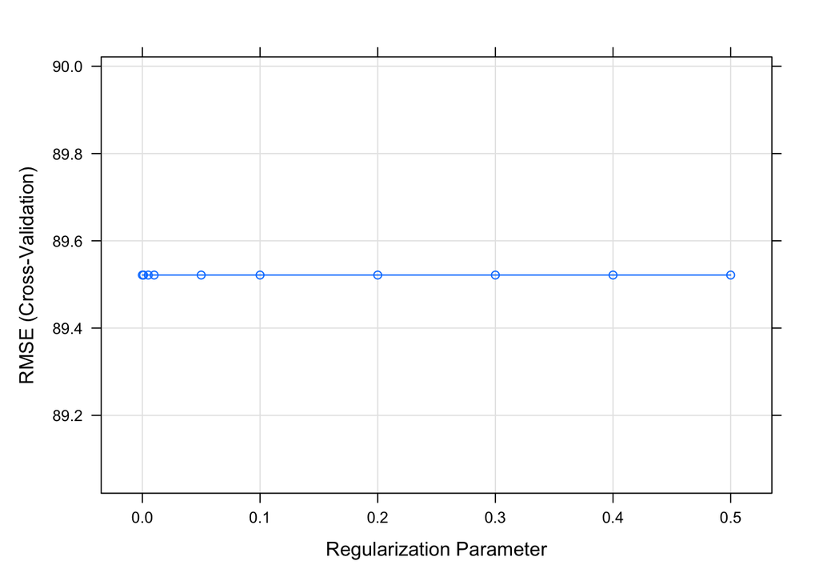

```r
plot(ridge)
```

```r
predicted_te <- predict(ridge, df2_te)

rmse_ridge <- sqrt(mean((df2_te$score - predicted_te)^2))
rmse_ridge
```

```
## [1] 89.75299
```

```r
rsq_ridge <- cor(df2_te$score,predicted_te)^2
rsq_ridge
```

```
## [1] 0.4040039
```

```r
mae_ridge <- mean(abs(df2_te$score - predicted_te))
mae_ridge
```

```
## [1] 69.51138
```

### Task 2.5. Use the caret::train() function to train a model with 10-fold cross-validation to predict the scores using lasso regression. Try different values of lambda to decide optimal value. Evaluate the performance of the model on the test dataset, and report RMSE, R-square, and MAE. Does lasso regression provide any improvement over linear regression with no regularization?

```r
grid <- data.frame(alpha = 1, lambda = c(0, .001,.005,.01,.05,.1,.2,.3,.4,.5))
                     #seq(0.01,3,.01))
grid
```

```
##    alpha lambda
## 1      1  0.000
## 2      1  0.001
## 3      1  0.005
## 4      1  0.010
## 5      1  0.050
## 6      1  0.100
## 7      1  0.200
## 8      1  0.300
## 9      1  0.400
## 10     1  0.500
```

```r
# Train the model

lasso <- train(blueprint_oregon,
                      data      = df2_tr,
                      method    = "glmnet",
                      trControl = cv,
                      tuneGrid  = grid)
lasso$results
```

```
##    alpha lambda     RMSE  Rsquared      MAE   RMSESD RsquaredSD     MAESD
## 1      1  0.000 89.52106 0.4015989 69.49778 1.084160 0.01011716 0.5652499
## 2      1  0.001 89.52106 0.4015989 69.49778 1.084160 0.01011716 0.5652499
## 3      1  0.005 89.52106 0.4015989 69.49778 1.084160 0.01011716 0.5652499
## 4      1  0.010 89.52106 0.4015989 69.49778 1.084160 0.01011716 0.5652499
## 5      1  0.050 89.52106 0.4015989 69.49778 1.084160 0.01011716 0.5652499
## 6      1  0.100 89.52093 0.4016018 69.49814 1.083992 0.01011404 0.5649350
## 7      1  0.200 89.52505 0.4015641 69.50537 1.083598 0.01011801 0.5639359
## 8      1  0.300 89.53164 0.4015047 69.51481 1.083332 0.01012328 0.5632038
## 9      1  0.400 89.54028 0.4014283 69.52601 1.083550 0.01013243 0.5627931
## 10     1  0.500 89.55127 0.4013311 69.53916 1.084049 0.01014447 0.5625914
```

```r
lasso$bestTune
```

```
##   alpha lambda
## 6     1    0.1
```

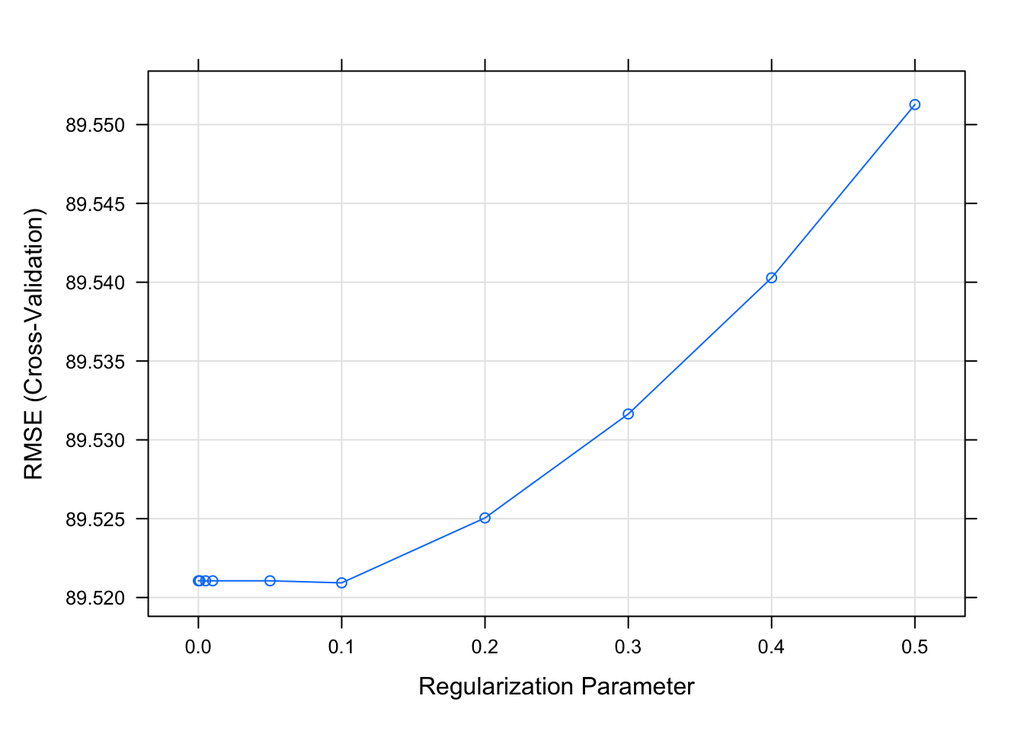

```r
plot(lasso)
```

```r
grid <- data.frame(alpha = 1, lambda = seq(0.0,0.05,.001))
grid
```

```
##    alpha lambda
## 1      1  0.000
## 2      1  0.001
## 3      1  0.002
## 4      1  0.003
## 5      1  0.004
## 6      1  0.005
## 7      1  0.006
## 8      1  0.007
## 9      1  0.008
## 10     1  0.009
## 11     1  0.010
## 12     1  0.011
## 13     1  0.012
## 14     1  0.013
```

[output cut: 37 more lines]

```r
# Train the model

lasso <- train(blueprint_oregon,
                      data      = df2_tr,
                      method    = "glmnet",
                      trControl = cv,
                      tuneGrid  = grid)
lasso$results
```

```
##    alpha lambda     RMSE  Rsquared      MAE  RMSESD RsquaredSD     MAESD
## 1      1  0.000 89.52106 0.4015989 69.49778 1.08416 0.01011716 0.5652499
## 2      1  0.001 89.52106 0.4015989 69.49778 1.08416 0.01011716 0.5652499
## 3      1  0.002 89.52106 0.4015989 69.49778 1.08416 0.01011716 0.5652499
## 4      1  0.003 89.52106 0.4015989 69.49778 1.08416 0.01011716 0.5652499
## 5      1  0.004 89.52106 0.4015989 69.49778 1.08416 0.01011716 0.5652499
## 6      1  0.005 89.52106 0.4015989 69.49778 1.08416 0.01011716 0.5652499
## 7      1  0.006 89.52106 0.4015989 69.49778 1.08416 0.01011716 0.5652499
## 8      1  0.007 89.52106 0.4015989 69.49778 1.08416 0.01011716 0.5652499
## 9      1  0.008 89.52106 0.4015989 69.49778 1.08416 0.01011716 0.5652499
## 10     1  0.009 89.52106 0.4015989 69.49778 1.08416 0.01011716 0.5652499
## 11     1  0.010 89.52106 0.4015989 69.49778 1.08416 0.01011716 0.5652499
## 12     1  0.011 89.52106 0.4015989 69.49778 1.08416 0.01011716 0.5652499
## 13     1  0.012 89.52106 0.4015989 69.49778 1.08416 0.01011716 0.5652499
## 14     1  0.013 89.52106 0.4015989 69.49778 1.08416 0.01011716 0.5652499
```

[output cut: 37 more lines]

```r
lasso$bestTune
```

```
##    alpha lambda
## 51     1   0.05
```

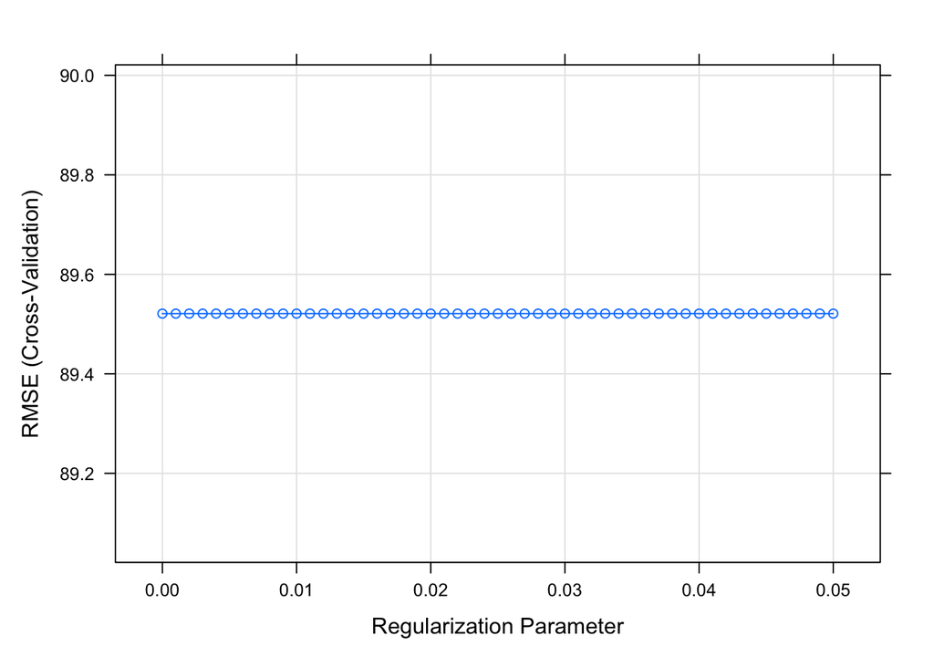

```r
plot(lasso)
```

```r
predicted_te <- predict(lasso, df2_te)

rmse_lasso <- sqrt(mean((df2_te$score - predicted_te)^2))
rmse_lasso
```

```
## [1] 89.75006
```

```r
rsq_lasso <- cor(df2_te$score,predicted_te)^2
rsq_lasso
```

```
## [1] 0.4039112
```

```r
mae_lasso <- mean(abs(df2_te$score - predicted_te))
mae_lasso
```

```
## [1] 69.50062
```

### Task 2.6 Evaluate the performance of the models in 2.2, 2.3, and 2.4 on the test dataset. Calculate and report the root mean squared error (RMSE), mean absolute error (MAE), and R-square. Summarize these numbers in a table like the following. Decide and comment on which model you would use to predict scores.

```r
name <- c('Linear Regression', 'Linear Regression with Ridge Penalty', 'Linear Regression with Lasso Penalty')
RMSE <- c(rmse_te, rmse_ridge, rmse_lasso)
MAE <- c(mae_te, mae_ridge, mae_lasso)
R_sq <- c(rsq_te, rsq_ridge, rsq_lasso)

summary_df <- data.frame(name, RMSE, MAE, R_sq)

summary_df
```

```
##                                   name     RMSE      MAE      R_sq
## 1                    Linear Regression 89.74221 69.49596 0.4039810
## 2 Linear Regression with Ridge Penalty 89.75299 69.51138 0.4040039
## 3 Linear Regression with Lasso Penalty 89.75006 69.50062 0.4039112
```

### Task 2.7 For the model you decided in 2.6, find and report the most important 10 predictors of test scores and their regression coefficients. Briefly comment which variables seem to be the most important predictors.

```r
coefs <- coef(lasso$finalModel,
              lasso$bestTune$lambda)

ind   <- order(abs(coefs[,1]),decreasing=T)

head(as.matrix(coefs[ind,]),10)
```

```
##                          [,1]
## (Intercept)        2526.56381
## tag_ed_fg_N        -123.91233
## na_ind_ind_ed_fg    108.03582
## sp_ed_fg_N           83.95855
## tst_bnch_X1B        -82.39562
## ethnic_cd_B         -57.12462
## na_ind_econ_dsvntg   54.00392
## econ_dsvntg_N        45.86588
## ethnic_cd_P         -37.21943
## ethnic_cd_A          32.58870
```

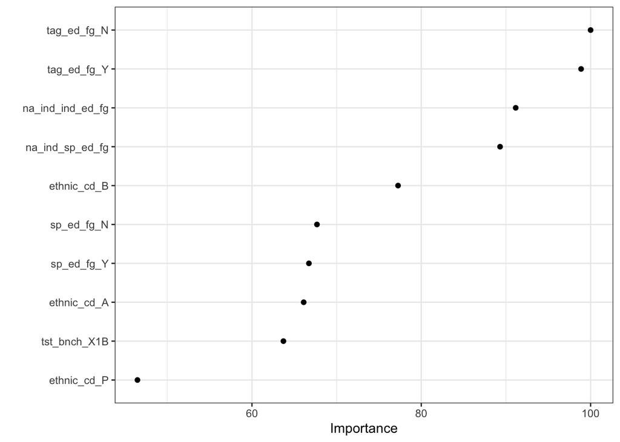

```r
vip::vip(ridge, num_features = 10, geom = "point") +
  theme_bw()
```

The most important predictor for score whether the student attends a Talented and Gifted program, which makes sense as the students attends a gifted program is more likely to perform better in the exam. It also shows that students who are native Americans and students who attends Individualized Education Plan (IEP/IFSP) also shows weaker exam scores, as the na of these columns leads to better performance.